# Risk Factor Analysis

## Outcome Variable

**Outcome Variable:** ever_co

## Predictor Variables

**Intervention Variable:** fhtcm

**Adjustment Set:**

- arm
- W_mage
- W_fage
- meducyrs
- feducyrs
- W_mhtcm
- W_mwtkg
- W_mbmi
- single
- delta_W_mage
- delta_W_fage
- delta_meducyrs
- delta_feducyrs
- delta_W_mhtcm
- delta_W_mwtkg
- delta_W_mbmi
- delta_single

## Stratifying Variables

The analysis was stratified on these variable(s):

- agecat
- studyid
- country

## Data Summary

| agecat | studyid | country | fhtcm | ever_co | n_cell | n |
| --- | --- | --- | --- | --- | --- | --- |
| 0-24 months | COHORTS | GUATEMALA | >=167 cm | 0 | 59 | 495 |
| 0-24 months | COHORTS | GUATEMALA | >=167 cm | 1 | 4 | 495 |
| 0-24 months | COHORTS | GUATEMALA | <162 cm | 0 | 244 | 495 |
| 0-24 months | COHORTS | GUATEMALA | <162 cm | 1 | 49 | 495 |
| 0-24 months | COHORTS | GUATEMALA | [162-167) cm | 0 | 119 | 495 |
| 0-24 months | COHORTS | GUATEMALA | [162-167) cm | 1 | 20 | 495 |
| 0-24 months | Keneba | GAMBIA | >=167 cm | 0 | 1062 | 1929 |
| 0-24 months | Keneba | GAMBIA | >=167 cm | 1 | 183 | 1929 |
| 0-24 months | Keneba | GAMBIA | <162 cm | 0 | 111 | 1929 |
| 0-24 months | Keneba | GAMBIA | <162 cm | 1 | 21 | 1929 |
| 0-24 months | Keneba | GAMBIA | [162-167) cm | 0 | 444 | 1929 |
| 0-24 months | Keneba | GAMBIA | [162-167) cm | 1 | 108 | 1929 |
| 0-24 months | PROBIT | BELARUS | >=167 cm | 0 | 11734 | 12537 |
| 0-24 months | PROBIT | BELARUS | >=167 cm | 1 | 10 | 12537 |
| 0-24 months | PROBIT | BELARUS | <162 cm | 0 | 167 | 12537 |
| 0-24 months | PROBIT | BELARUS | <162 cm | 1 | 1 | 12537 |
| 0-24 months | PROBIT | BELARUS | [162-167) cm | 0 | 622 | 12537 |
| 0-24 months | PROBIT | BELARUS | [162-167) cm | 1 | 3 | 12537 |
| 0-24 months | SAS-CompFeed | INDIA | >=167 cm | 0 | 327 | 895 |
| 0-24 months | SAS-CompFeed | INDIA | >=167 cm | 1 | 80 | 895 |
| 0-24 months | SAS-CompFeed | INDIA | <162 cm | 0 | 162 | 895 |
| 0-24 months | SAS-CompFeed | INDIA | <162 cm | 1 | 64 | 895 |
| 0-24 months | SAS-CompFeed | INDIA | [162-167) cm | 0 | 196 | 895 |
| 0-24 months | SAS-CompFeed | INDIA | [162-167) cm | 1 | 66 | 895 |
| 0-24 months | SAS-FoodSuppl | INDIA | >=167 cm | 0 | 73 | 399 |
| 0-24 months | SAS-FoodSuppl | INDIA | >=167 cm | 1 | 33 | 399 |
| 0-24 months | SAS-FoodSuppl | INDIA | <162 cm | 0 | 84 | 399 |
| 0-24 months | SAS-FoodSuppl | INDIA | <162 cm | 1 | 79 | 399 |
| 0-24 months | SAS-FoodSuppl | INDIA | [162-167) cm | 0 | 91 | 399 |
| 0-24 months | SAS-FoodSuppl | INDIA | [162-167) cm | 1 | 39 | 399 |

[output cut: 60 more lines]

The following strata were considered:

- agecat: 0-24 months, studyid: COHORTS, country: GUATEMALA
- agecat: 0-24 months, studyid: Keneba, country: GAMBIA
- agecat: 0-24 months, studyid: PROBIT, country: BELARUS
- agecat: 0-24 months, studyid: SAS-CompFeed, country: INDIA
- agecat: 0-24 months, studyid: SAS-FoodSuppl, country: INDIA
- agecat: 0-6 months, studyid: COHORTS, country: GUATEMALA
- agecat: 0-6 months, studyid: Keneba, country: GAMBIA
- agecat: 0-6 months, studyid: PROBIT, country: BELARUS
- agecat: 0-6 months, studyid: SAS-CompFeed, country: INDIA
- agecat: 0-6 months, studyid: SAS-FoodSuppl, country: INDIA
- agecat: 6-24 months, studyid: COHORTS, country: GUATEMALA
- agecat: 6-24 months, studyid: Keneba, country: GAMBIA
- agecat: 6-24 months, studyid: PROBIT, country: BELARUS
- agecat: 6-24 months, studyid: SAS-CompFeed, country: INDIA
- agecat: 6-24 months, studyid: SAS-FoodSuppl, country: INDIA

### Dropped Strata

Some strata were dropped due to rare outcomes:

- agecat: 0-24 months, studyid: COHORTS, country: GUATEMALA
- agecat: 0-24 months, studyid: PROBIT, country: BELARUS
- agecat: 0-6 months, studyid: COHORTS, country: GUATEMALA
- agecat: 0-6 months, studyid: Keneba, country: GAMBIA
- agecat: 0-6 months, studyid: PROBIT, country: BELARUS
- agecat: 6-24 months, studyid: COHORTS, country: GUATEMALA
- agecat: 6-24 months, studyid: PROBIT, country: BELARUS

## Methods Detail

We’re interested in the causal parameters $E[Y_a]$ for all values of $a \in \mathcal{A}$. These parameters represent the mean outcome if, possibly contrary to fact, we intervened to set all units to have $A=a$. Under the randomization and positivity assumptions, these are identified by the statistical parameters $\psi_a=E_W[E_{Y|A,W}(Y|A=a,W)]$. In addition, we’re interested in the mean of $Y$, $E[Y]$ under no intervention (the observed mean). We will estimate these parameters by using SuperLearner to fit the relevant likelihood factors – $E_{Y|A,W}(Y|A=a,W)$ and $p(A=a|W)$, and then updating our likelihood fit using a joint TMLE.

For unadjusted analyses ($W=\{\}$), initial likelihoods were estimated using Lrnr_glm to estimate the simple $E(Y|A)$ and Lrnr_mean to estimate $p(A)$. For adjusted analyses, a small library containing Lrnr_glmnet, Lrnr_xgboost, and Lrnr_mean was used.

Having estimated these parameters, we will then use the delta method to estimate relative risks and attributable risks relative to a prespecified baseline level of $A$.

# Results Detail

## Results Plots

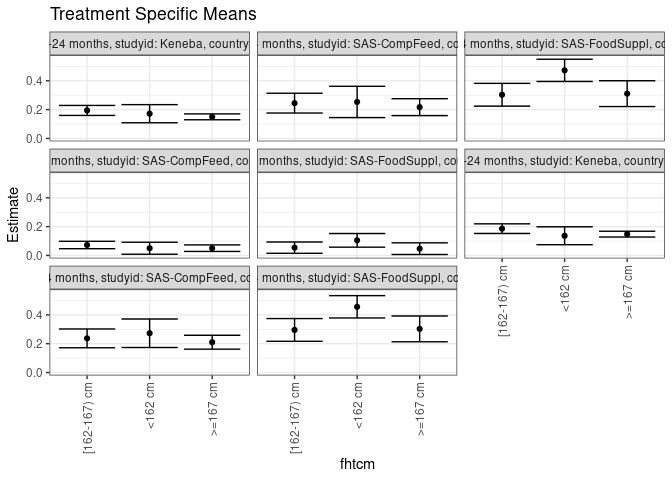

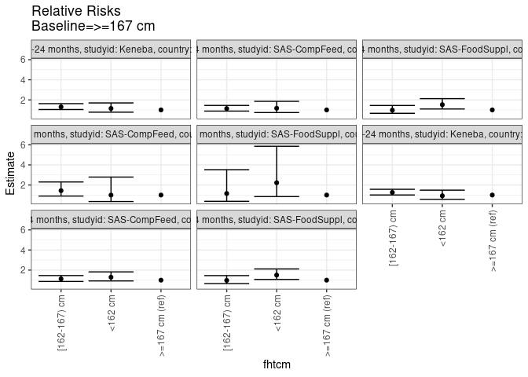

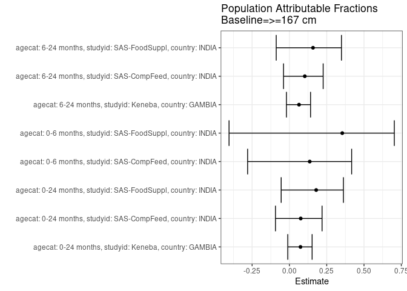

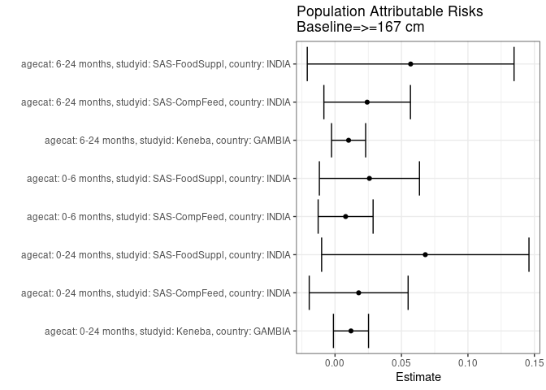

## Results Table

### Parameter: TSM

| agecat | studyid | country | intervention_level | baseline_level | estimate | ci_lower | ci_upper |
| --- | --- | --- | --- | --- | --- | --- | --- |
| 0-24 months | Keneba | GAMBIA | >=167 cm | NA | 0.1497347 | 0.1292905 | 0.1701788 |
| 0-24 months | Keneba | GAMBIA | <162 cm | NA | 0.1716128 | 0.1087224 | 0.2345031 |
| 0-24 months | Keneba | GAMBIA | [162-167) cm | NA | 0.1940473 | 0.1593376 | 0.2287570 |
| 0-24 months | SAS-CompFeed | INDIA | >=167 cm | NA | 0.2168428 | 0.1582341 | 0.2754515 |
| 0-24 months | SAS-CompFeed | INDIA | <162 cm | NA | 0.2529381 | 0.1444020 | 0.3614743 |
| 0-24 months | SAS-CompFeed | INDIA | [162-167) cm | NA | 0.2447533 | 0.1760731 | 0.3134335 |
| 0-24 months | SAS-FoodSuppl | INDIA | >=167 cm | NA | 0.3105235 | 0.2209373 | 0.4001096 |
| 0-24 months | SAS-FoodSuppl | INDIA | <162 cm | NA | 0.4722620 | 0.3950968 | 0.5494272 |
| 0-24 months | SAS-FoodSuppl | INDIA | [162-167) cm | NA | 0.3029572 | 0.2239456 | 0.3819688 |
| 0-6 months | SAS-CompFeed | INDIA | >=167 cm | NA | 0.0505825 | 0.0279499 | 0.0732152 |
| 0-6 months | SAS-CompFeed | INDIA | <162 cm | NA | 0.0503320 | 0.0086811 | 0.0919829 |
| 0-6 months | SAS-CompFeed | INDIA | [162-167) cm | NA | 0.0726854 | 0.0470632 | 0.0983075 |
| 0-6 months | SAS-FoodSuppl | INDIA | >=167 cm | NA | 0.0471698 | 0.0067604 | 0.0875792 |
| 0-6 months | SAS-FoodSuppl | INDIA | <162 cm | NA | 0.1049383 | 0.0576850 | 0.1521915 |
| 0-6 months | SAS-FoodSuppl | INDIA | [162-167) cm | NA | 0.0542636 | 0.0151218 | 0.0934053 |
| 6-24 months | Keneba | GAMBIA | >=167 cm | NA | 0.1481738 | 0.1280424 | 0.1683053 |
| 6-24 months | Keneba | GAMBIA | <162 cm | NA | 0.1367672 | 0.0746129 | 0.1989214 |
| 6-24 months | Keneba | GAMBIA | [162-167) cm | NA | 0.1861209 | 0.1527365 | 0.2195053 |
| 6-24 months | SAS-CompFeed | INDIA | >=167 cm | NA | 0.2102692 | 0.1621049 | 0.2584335 |
| 6-24 months | SAS-CompFeed | INDIA | <162 cm | NA | 0.2724844 | 0.1736384 | 0.3713305 |
| 6-24 months | SAS-CompFeed | INDIA | [162-167) cm | NA | 0.2368940 | 0.1716745 | 0.3021135 |
| 6-24 months | SAS-FoodSuppl | INDIA | >=167 cm | NA | 0.3027894 | 0.2134629 | 0.3921159 |
| 6-24 months | SAS-FoodSuppl | INDIA | <162 cm | NA | 0.4559002 | 0.3783923 | 0.5334080 |
| 6-24 months | SAS-FoodSuppl | INDIA | [162-167) cm | NA | 0.2954483 | 0.2165390 | 0.3743576 |

### Parameter: E(Y)

| agecat | studyid | country | intervention_level | baseline_level | estimate | ci_lower | ci_upper |
| --- | --- | --- | --- | --- | --- | --- | --- |
| 0-24 months | Keneba | GAMBIA | NA | NA | 0.1617418 | 0.1453059 | 0.1781778 |
| 0-24 months | SAS-CompFeed | INDIA | NA | NA | 0.2346369 | 0.1798928 | 0.2893809 |
| 0-24 months | SAS-FoodSuppl | INDIA | NA | NA | 0.3784461 | 0.3307978 | 0.4260945 |
| 0-6 months | SAS-CompFeed | INDIA | NA | NA | 0.0585586 | 0.0394255 | 0.0776916 |
| 0-6 months | SAS-FoodSuppl | INDIA | NA | NA | 0.0730479 | 0.0474188 | 0.0986769 |
| 6-24 months | Keneba | GAMBIA | NA | NA | 0.1583784 | 0.1417371 | 0.1750196 |
| 6-24 months | SAS-CompFeed | INDIA | NA | NA | 0.2344498 | 0.1848813 | 0.2840182 |
| 6-24 months | SAS-FoodSuppl | INDIA | NA | NA | 0.3596939 | 0.3121253 | 0.4072624 |

### Parameter: RR

| agecat | studyid | country | intervention_level | baseline_level | estimate | ci_lower | ci_upper |
| --- | --- | --- | --- | --- | --- | --- | --- |
| 0-24 months | Keneba | GAMBIA | >=167 cm | >=167 cm | 1.0000000 | 1.0000000 | 1.000000 |
| 0-24 months | Keneba | GAMBIA | <162 cm | >=167 cm | 1.1461124 | 0.7760390 | 1.692665 |
| 0-24 months | Keneba | GAMBIA | [162-167) cm | >=167 cm | 1.2959411 | 1.0356696 | 1.621621 |
| 0-24 months | SAS-CompFeed | INDIA | >=167 cm | >=167 cm | 1.0000000 | 1.0000000 | 1.000000 |
| 0-24 months | SAS-CompFeed | INDIA | <162 cm | >=167 cm | 1.1664585 | 0.7351827 | 1.850731 |
| 0-24 months | SAS-CompFeed | INDIA | [162-167) cm | >=167 cm | 1.1287131 | 0.8818328 | 1.444711 |
| 0-24 months | SAS-FoodSuppl | INDIA | >=167 cm | >=167 cm | 1.0000000 | 1.0000000 | 1.000000 |
| 0-24 months | SAS-FoodSuppl | INDIA | <162 cm | >=167 cm | 1.5208577 | 1.0908818 | 2.120311 |
| 0-24 months | SAS-FoodSuppl | INDIA | [162-167) cm | >=167 cm | 0.9756339 | 0.6615345 | 1.438869 |
| 0-6 months | SAS-CompFeed | INDIA | >=167 cm | >=167 cm | 1.0000000 | 1.0000000 | 1.000000 |
| 0-6 months | SAS-CompFeed | INDIA | <162 cm | >=167 cm | 0.9950465 | 0.3551608 | 2.787801 |
| 0-6 months | SAS-CompFeed | INDIA | [162-167) cm | >=167 cm | 1.4369656 | 0.8968498 | 2.302359 |
| 0-6 months | SAS-FoodSuppl | INDIA | >=167 cm | >=167 cm | 1.0000000 | 1.0000000 | 1.000000 |
| 0-6 months | SAS-FoodSuppl | INDIA | <162 cm | >=167 cm | 2.2246914 | 0.8451872 | 5.855805 |
| 0-6 months | SAS-FoodSuppl | INDIA | [162-167) cm | >=167 cm | 1.1503876 | 0.3753798 | 3.525474 |
| 6-24 months | Keneba | GAMBIA | >=167 cm | >=167 cm | 1.0000000 | 1.0000000 | 1.000000 |
| 6-24 months | Keneba | GAMBIA | <162 cm | >=167 cm | 0.9230184 | 0.5745152 | 1.482925 |
| 6-24 months | Keneba | GAMBIA | [162-167) cm | >=167 cm | 1.2560983 | 1.0032918 | 1.572606 |
| 6-24 months | SAS-CompFeed | INDIA | >=167 cm | >=167 cm | 1.0000000 | 1.0000000 | 1.000000 |
| 6-24 months | SAS-CompFeed | INDIA | <162 cm | >=167 cm | 1.2958839 | 0.9210838 | 1.823195 |
| 6-24 months | SAS-CompFeed | INDIA | [162-167) cm | >=167 cm | 1.1266225 | 0.8709960 | 1.457272 |
| 6-24 months | SAS-FoodSuppl | INDIA | >=167 cm | >=167 cm | 1.0000000 | 1.0000000 | 1.000000 |
| 6-24 months | SAS-FoodSuppl | INDIA | <162 cm | >=167 cm | 1.5056677 | 1.0703477 | 2.118036 |
| 6-24 months | SAS-FoodSuppl | INDIA | [162-167) cm | >=167 cm | 0.9757552 | 0.6553615 | 1.452783 |

### Parameter: PAR

| agecat | studyid | country | intervention_level | baseline_level | estimate | ci_lower | ci_upper |
| --- | --- | --- | --- | --- | --- | --- | --- |
| 0-24 months | Keneba | GAMBIA | >=167 cm | NA | 0.0120072 | -0.0011878 | 0.0252021 |
| 0-24 months | SAS-CompFeed | INDIA | >=167 cm | NA | 0.0177941 | -0.0194076 | 0.0549957 |
| 0-24 months | SAS-FoodSuppl | INDIA | >=167 cm | NA | 0.0679227 | -0.0100768 | 0.1459221 |
| 0-6 months | SAS-CompFeed | INDIA | >=167 cm | NA | 0.0079760 | -0.0126993 | 0.0286513 |
| 0-6 months | SAS-FoodSuppl | INDIA | >=167 cm | NA | 0.0258780 | -0.0117754 | 0.0635315 |
| 6-24 months | Keneba | GAMBIA | >=167 cm | NA | 0.0102045 | -0.0026259 | 0.0230350 |
| 6-24 months | SAS-CompFeed | INDIA | >=167 cm | NA | 0.0241806 | -0.0083805 | 0.0567417 |
| 6-24 months | SAS-FoodSuppl | INDIA | >=167 cm | NA | 0.0569045 | -0.0208803 | 0.1346893 |

### Parameter: PAF

| agecat | studyid | country | intervention_level | baseline_level | estimate | ci_lower | ci_upper |
| --- | --- | --- | --- | --- | --- | --- | --- |
| 0-24 months | Keneba | GAMBIA | >=167 cm | NA | 0.0742367 | -0.0109276 | 0.1522264 |
| 0-24 months | SAS-CompFeed | INDIA | >=167 cm | NA | 0.0758366 | -0.0933894 | 0.2188712 |
| 0-24 months | SAS-FoodSuppl | INDIA | >=167 cm | NA | 0.1794777 | -0.0551309 | 0.3619211 |
| 0-6 months | SAS-CompFeed | INDIA | >=167 cm | NA | 0.1362057 | -0.2801313 | 0.4171375 |
| 0-6 months | SAS-FoodSuppl | INDIA | >=167 cm | NA | 0.3542615 | -0.4046217 | 0.7031385 |
| 6-24 months | Keneba | GAMBIA | >=167 cm | NA | 0.0644313 | -0.0198719 | 0.1417660 |
| 6-24 months | SAS-CompFeed | INDIA | >=167 cm | NA | 0.1031376 | -0.0394791 | 0.2261873 |
| 6-24 months | SAS-FoodSuppl | INDIA | >=167 cm | NA | 0.1582026 | -0.0884542 | 0.3489640 |